# Targeted learning lab

Yazhuo Deng

January 20, 2019

## 0.1 Lab 1 - Defining the Causal Parameter

### 0.1.1 simulate data

```r
# 1. setting the seed
set.seed(252)
#2. setting the number of observations
n<- 5000
#3. simulating the Us
U.W1<- runif(n, min=0, max=1)
U.W2<- rbinom(n, size=1, prob=0.5)
U.A<- rnorm(n, mean=-3, sd=1)
U.Y<- rnorm(n, mean=0, sd=0.3)
#4.  Given the random input, deterministically evaluate the structural equations F
W1 = as.numeric( U.W1 < 0.35)
W2 = W1 + 2*U.W2
A = as.numeric( 1+W1+2*W2 + U.A > 0)
Y = 1 +2.5*A + 3*W1 - 0.25*A*W1 + U.Y
X<- data.frame(W1, W2, A, Y)
head(X)
```

```
##   W1 W2 A         Y
## 1  0  2 1 3.3561085
## 2  0  0 0 0.8793806
## 3  1  1 0 3.3546226
## 4  0  2 1 3.5474294
## 5  0  0 0 0.4332530
## 6  0  2 1 3.6398616
```

```r
summary(X)
```

```
##        W1               W2              A                Y
##  Min.   :0.0000   Min.   :0.000   Min.   :0.0000   Min.   :0.07914
##  1st Qu.:0.0000   1st Qu.:0.000   1st Qu.:0.0000   1st Qu.:1.22898
##  Median :0.0000   Median :2.000   Median :1.0000   Median :3.50644
##  Mean   :0.3372   Mean   :1.338   Mean   :0.6456   Mean   :3.55352
##  3rd Qu.:1.0000   3rd Qu.:2.000   3rd Qu.:1.0000   3rd Qu.:6.00153
##  Max.   :1.0000   Max.   :3.000   Max.   :1.0000   Max.   :7.16974
```

### 0.1.2 Generate the counterfactual outcomes & obtain the value of the target causal parameter

```r
# 1. intervene to set A=a and generate the counterfactual outcomes Y.a
Y.1<- 1 +2.5*1 + 3*W1 - 0.25*1*W1 + U.Y
Y.0<- 1 +2.5*0 + 3*W1 - 0.25*0*W1 + U.Y
# 2. add these columns to the dataframe
X<- data.frame(X, Y.1, Y.0)
head(X)
```

```
##   W1 W2 A         Y      Y.1       Y.0
## 1  0  2 1 3.3561085 3.356108 0.8561085
## 2  0  0 0 0.8793806 3.379381 0.8793806
## 3  1  1 0 3.3546226 5.604623 3.3546226
## 4  0  2 1 3.5474294 3.547429 1.0474294
## 5  0  0 0 0.4332530 2.933253 0.4332530
## 6  0  2 1 3.6398616 3.639862 1.1398616
```

```r
#3. YES! We see the outcome Y when A=0 is equal to the counterfactual outcome Y.0.
# Likewise, the outcome Y when A=1 is equal to the counterfactual outcome Y.1.
# Given input of the background factors U, the structural equations are deterministic.
#4. Evaluation
Psi.F<- mean(Y.1 - Y.0)
Psi.F
```

```
## [1] 2.4157
```

### 0.1.3 Target causal parameters defined with a marginal structural model (MSM)

Suppose we are now interested in summarizing how the expectation of counterfactual happiness Ya varies as a function of cups of butterbeer consumed a. We will assume that the latest wizarding technology allows precise measurement of the amount of butterbeer consumed so that a may take on decimal values.

```r
# 1. making the data frame
n=5
# generating the exogenous Us
U.A <- runif(n, min=0, max=2)
U.Y <- rnorm(n, mean=0, sd=0.3)
# Evaluating the counterfactuals
Y.0<- 4 +9*0-2.25*0*0+ U.Y
Y.1<- 4 +9*1-2.25*1*1+ U.Y
Y.2<- 4 +9*2-2.25*2*2+ U.Y
Y.3<- 4 +9*3-2.25*3*3+ U.Y
Y.4<- 4 +9*4-2.25*4*4+ U.Y
# 2. making the dataframe
# c() combines values into a vector.
Y.a<- c(Y.0, Y.1, Y.2, Y.3, Y.4)

# To get a vector of the corresponding treatments use the rep() function
a<- c( rep(0,n), rep(1, n), rep(2, n), rep(3, n), rep(4, n) )

X<- data.frame(a,Y.a)
head(X)
```

```
##   a       Y.a
## 1 0  4.244533
## 2 0  3.930170
## 3 0  4.502727
## 4 0  3.775410
## 5 0  4.077615
## 6 1 10.994533
```

```r
summary(X)
```

```
##        a          Y.a
##  Min.   :0   Min.   : 3.775
##  1st Qu.:1   1st Qu.: 4.245
##  Median :2   Median :10.680
##  Mean   :2   Mean   : 8.606
##  3rd Qu.:3   3rd Qu.:11.253
##  Max.   :4   Max.   :13.503
```

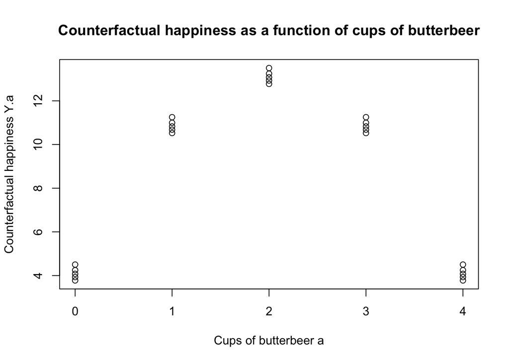

```r
# 3. Plotting the counterfactuals
# plot the counterfactual happiness as a function of cups of butterbeer consumed
# adding a title and label axes
plot(a, Y.a, main='Counterfactual happiness as a function of cups of butterbeer',
     xlab='Cups of butterbeer a', ylab='Counterfactual happiness Y.a')
```

Based on our knowledge of the data generating system as well as the previous graph, the working MSM is a poor summary of how counterfactual happiness changes with cups of butterbeer consumed. The true functional relationship is quadratic.

### 0.1.4 Obtain the value of the target causal parameter

```r
############
# 1. Evaluate the value of the target causal parameter.
# We can use ordinary least squares regression to obtain betas.
workMSM<- glm(Y.a ~ a)

# the target parameter are the coefficient value that minimize the L2 risk function
workMSM
```

```
##
## Call:  glm(formula = Y.a ~ a)
##
## Coefficients:
## (Intercept)            a
##   8.606e+00   -3.140e-16
##
## Degrees of Freedom: 24 Total (i.e. Null);  23 Residual
## Null Deviance:       356
## Residual Deviance: 356   AIC: 143.3
```

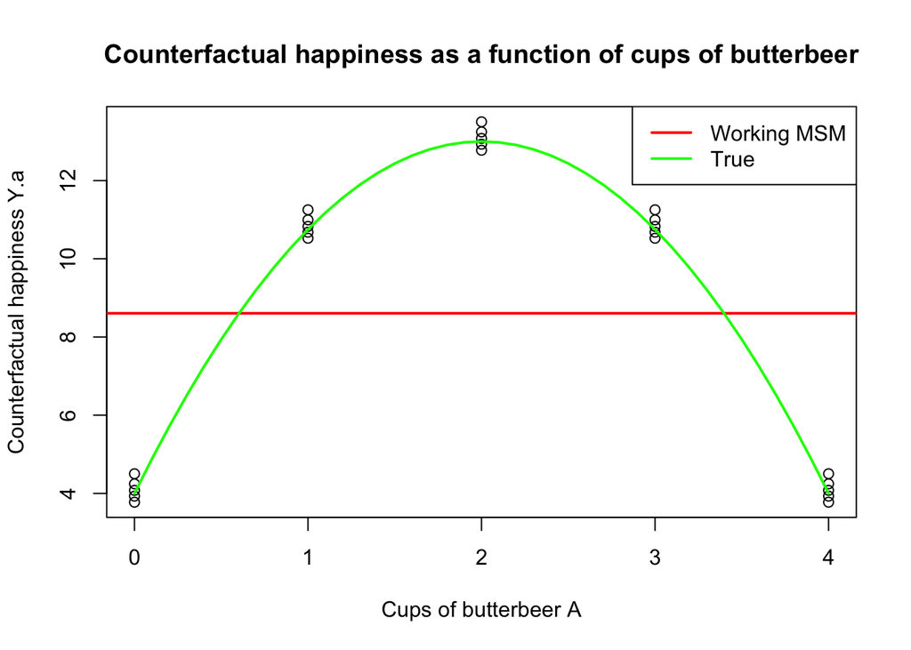

```r
###############
#2. Add the projected causal curve to the graph.
plot(a, Y.a, main='Counterfactual happiness as a function of cups of butterbeer',     xlab='Cups of butterbeer A', ylab='Counterfactual happiness Y.a')
abline(workMSM, col='red', lwd=2)
# we are specifying red for the color and increasing the line width (lwd)
##############
#3. Add the true causal curve to the graph.
# using the seq() function, we can get a lot of points between A=0 and A=4
A.cont<- seq(from=0, to=4, by=0.1)
# then we can evaluate the mean counterfactual at all these points
Y.a.cont<- 4 +9*A.cont-2.25*A.cont*A.cont
lines(A.cont, Y.a.cont, col='green', lwd=2)
# we are specifying green for the color and increasing the line width (lwd)
# we can add a legend
legend('topright', c('Working MSM', 'True'), col=c('red', 'green'), lwd=2)
```

## 0.2 Lab 2 - Identifiability & the Simple Substitution Estimator

```r
# simulate data
# 1. set the seed
set.seed(252)
# 2. set the number of draws
n <- 5000
# 3. Draw n i.i.d. observations
U.W1<- runif(n, min=0, max=1)
U.W2<- rnorm(n, mean=1, sd=2)
U.A <- runif(n, min=0, max=1)
U.Y <- runif(n, min=0, max=1)
U.W3<- runif(n, min=0, max=1)
W1<- as.numeric( U.W1 < 0.45)
W2<- 0.75*U.W2
A <- as.numeric( U.A < plogis(-1+2.6*W1+0.9*W2))
Y <- as.numeric( U.Y < plogis(-2+A+0.7*W1))
W3<- as.numeric( U.W3 < plogis(-1 + 1.3*A + 2.9*Y))
# 4. dataframe O for the observed data.
Obs<- data.frame(W1, W2, A, Y, W3)
head(Obs)
```

```
##   W1         W2 A Y W3
## 1  0  0.9012694 1 0  1
## 2  0 -0.2273375 0 0  1
## 3  1  0.5045215 1 1  1
## 4  0  1.2643669 1 0  1
## 5  0  5.3133210 1 1  1
## 6  1  1.2645811 1 0  0
```

```r
summary(Obs)
```

```
##        W1               W2                A                Y
##  Min.   :0.0000   Min.   :-4.0200   Min.   :0.0000   Min.   :0.0000
##  1st Qu.:0.0000   1st Qu.:-0.2676   1st Qu.:0.0000   1st Qu.:0.0000
##  Median :0.0000   Median : 0.7765   Median :1.0000   Median :0.0000
##  Mean   :0.4362   Mean   : 0.7356   Mean   :0.6168   Mean   :0.2712
##  3rd Qu.:1.0000   3rd Qu.: 1.7261   3rd Qu.:1.0000   3rd Qu.:1.0000
##  Max.   :1.0000   Max.   : 7.5540   Max.   :1.0000   Max.   :1.0000
##        W3
##  Min.   :0.0000
##  1st Qu.:0.0000
##  Median :1.0000
##  Mean   :0.5692
##  3rd Qu.:1.0000
##  Max.   :1.0000
```

```r
#-------------------------------------------------------
#generating variables (alternative way)

#W1 <-rbinom(n, size=1, prob=0.45)
#W2 <- 0.75*rnorm(n, mean=1, sd=2)
#A <- rbinom(n, size=1, prob=plogis(-1+2.6*W1+0.9*W2))
#Y <- rbinom(n, size=1, prob=plogis(-2+A+0.7*W1))
#W3<- rbinom(n, size=1, prob=plogis(-1+1.3*A+2.9*Y))
```

### 0.2.1 Simple substitution estimator based on the G-Computation formula

```r
# 1. Estimating E(Y|A,W) with non-parametric maximum likelihood estimator (NPMLE)
#Estimate the conditional mean function with the (NPMLE).
# mean outcome among unexposed females
meanY.a0w0<- mean(Y[W1==0 & A==0])
meanY.a0w0
```

```
## [1] 0.1207116
```

```r
# mean outcome among exposed females
meanY.a1w0<- mean(Y[W1==0 & A==1])
meanY.a1w0
```

```
## [1] 0.2586345
```

```r
# mean outcome among unexposed males
meanY.a0w1<- mean(Y[W1==1 & A==0])
meanY.a0w1
```

```
## [1] 0.2017544
```

```r
# mean outcome among exposed males
meanY.a1w1<- mean(Y[W1==1 & A==1])
meanY.a1w1
```

```
## [1] 0.4214247
```

```r
# 2 Estimating the marginal distribution P(W1) with the NPMLE
# prob W1=1 is simple the mean of W1
mean(W1)
```

```
## [1] 0.4362
```

```r
# 3. Substitute the estimates into the target parameter mapping (G-comp formula)
Psi.hat<- (meanY.a1w1 - meanY.a0w1)*mean(W1) + (meanY.a1w0 - meanY.a0w0)*(1-mean(W1))
Psi.hat
```

```
## [1] 0.1735812
```

### 0.2.2 Implementation with a “saturated” parametric regression

```r
#1. Estimate the conditional mean of Y given the treatment A and W1
reg.model<- glm(Y ~A + W1+ A*W1, family='binomial', data=Obs)
reg.model
```

```
##
## Call:  glm(formula = Y ~ A + W1 + A * W1, family = "binomial", data = Obs)
##
## Coefficients:
## (Intercept)            A           W1         A:W1
##     -1.9857       0.9326       0.6103       0.1258
##
## Degrees of Freedom: 4999 Total (i.e. Null);  4996 Residual
## Null Deviance:       5844
## Residual Deviance: 5431  AIC: 5439
```

```r
#2. Copy the original dataset O into two new dataframes txt and control
txt<- control <- Obs
# set A=1 in the txt dataframe and A=0 in control dataframe
txt$A <-1
control$A <- 0
# 3 predict the mean outcome for each individual in the sample under the treatment
predictY.txt<- predict(reg.model, newdata = txt, type='response')
# 4. predict the mean outcome for each individual in the sample under the control
predictY.control<- predict(reg.model, newdata = control, type='response')

head(cbind(W1,W2,A,Y, W3, predictY.txt, predictY.control))
```

```
##   W1         W2 A Y W3 predictY.txt predictY.control
## 1  0  0.9012694 1 0  1    0.2586345        0.1207116
## 2  0 -0.2273375 0 0  1    0.2586345        0.1207116
## 3  1  0.5045215 1 1  1    0.4214247        0.2017544
## 4  0  1.2643669 1 0  1    0.2586345        0.1207116
## 5  0  5.3133210 1 1  1    0.2586345        0.1207116
## 6  1  1.2645811 1 0  0    0.4214247        0.2017544
```

```r
tail(cbind(W1,W2,A,Y, W3, predictY.txt, predictY.control))
```

```
##      W1         W2 A Y W3 predictY.txt predictY.control
## 4995  1  2.7779075 1 0  1    0.4214247        0.2017544
## 4996  0  1.1455181 0 0  0    0.2586345        0.1207116
## 4997  0  2.0852541 0 0  0    0.2586345        0.1207116
## 4998  0  0.5176812 1 1  1    0.2586345        0.1207116
## 4999  0 -1.5372069 0 0  1    0.2586345        0.1207116
## 5000  1  0.2457420 1 1  1    0.4214247        0.2017544
```

```r
# 5. take the mean of the predicted outcomes to average over the distribution of W1
mean(predictY.txt - predictY.control)
```

```
## [1] 0.1735812
```

```r
# 1. setting the number of iterations and the sample size
R <- 500
n <- 200
# 2. create a vector for the estimates
estimates<- rep(NA,R)
# 3. repeat the data generating experiment and estimation algorithm R times
for(i in 1:R){
  # 1. simulate the sample of n observations
  # (using simplified code here - see Sect3)
  W1 <-rbinom(n, size=1, prob=0.45)
  W2 <- 0.75*rnorm(n, mean=1, sd=2)
  A <- rbinom(n, size=1, prob=plogis(-1+2.6*W1+0.9*W2))
  Y <- rbinom(n, size=1, prob=plogis(-2+A+0.7*W1))
  W3<- rbinom(n, size=1, prob=plogis(-1+1.3*A+2.9*Y))
  Obs<- data.frame(W1,W2,A,Y,W3)
  #2  Estimate the conditional mean of Y given the treatment A and W1
  reg.model<- glm(Y ~ A + W1 + A*W1, family='binomial', data=Obs)
  #3. Copy the original dataset O into two new dataframes txt and control.
  txt<- control <- Obs
  # set A=1 in the txt dataframe and A=0 in control dataframe
  txt$A <-1
  control$A <-0
  # 4 predict the outcome for each individual in the sample under the treatment
  predictY.txt<- predict(reg.model, newdata = txt, type='response')
  # 5 predict the outcome for each individual in the sample under the control
  predictY.control<- predict(reg.model, newdata = control, type='response')
  # 6.  take the mean of the predicted outcomes over the distribution of W1
  estimates[i]<- mean(predictY.txt - predictY.control)
  }
# 3-6  average value, bias, variance, and MSE of the estimator
meanEst<- mean(estimates)
meanEst
```

```
## [1] 0.1805442
```

```r
# True estimator
# in R the logit^{-1} function is equal to plogis
Psi.P0<- (plogis(-2+1+0.7*1) - plogis(-2+0+0.7*1) )*0.45 +
  (plogis(-2+1+0.7*0) - plogis(-2+0+0.7*0))* 0.55
Psi.P0
```

```
## [1] 0.1774828
```

```r
#bias
bias<- mean(estimates - Psi.P0)
bias
```

```
## [1] 0.003061437
```

```r
#variance
var<- var(estimates)
var
```

```
## [1] 0.004863207
```

```r
#mean squared error
mse<- mean( (estimates-Psi.P0)^2)
mse
```

```
## [1] 0.004862853
```

```r
# check that mse=bias^2 + var
```

### 0.2.4 More practice (misspecified model)

```r
estimates.miss <- rep(NA,R)
for(i in 1:R){
  # simulate the sample of n=200 observations
  W1 <-rbinom(n, size=1, prob=0.45)
  W2 <- 0.75*rnorm(n, mean=1, sd=2)
  A <- rbinom(n, size=1, prob=plogis(-1+2.6*W1+0.9*W2))
  Y <- rbinom(n, size=1, prob=plogis(-2+A+0.7*W1))
  W3<- rbinom(n, size=1, prob=plogis(-1+1.3*A+2.9*Y))
  Obs<- data.frame(W1,W2,A,Y,W3)
  #2  Estimate the conditional mean of Y given the treatment A, W1, W2,W3
  miss.reg.model<- glm(Y ~ A + W1 +W2+W3, family='binomial', data=Obs)
  #3. Copy the original dataset O into two new dataframes txtPop and controlPop.
  txt<- control <- Obs
  # set A=1 in the txt dataframe and A=0 in control dataframe
  txt$A <-1
  control$A <- 0
  # 4 predict the outcome for each individual in the sample under the treatment
  predictY.txt<- predict(miss.reg.model, newdata = txt, type='response')
  # 5. predict the outcome for each individual in the sample under the control
  predictY.control<- predict(miss.reg.model, newdata = control, type='response')
  # 6.  take the mean of the predicted outcomes over the distribution of W1
  estimates.miss[i]<- mean(predictY.txt - predictY.control)
}

# Evaluating the estimator
meanEst.miss<- mean(estimates.miss)
bias.miss<- mean(estimates.miss - Psi.P0)
var.miss<- var(estimates.miss)
mse.miss<- mean( (estimates.miss-Psi.P0)^2)
# 3. compare bias, variance, mse of substitution estimators
estComparison<- data.frame(rbind(c(meanEst, bias, var, mse),
                                c(meanEst.miss, bias.miss, var.miss, mse.miss)))
rownames(estComparison)<- c('Correctly', 'Misspecified')
colnames(estComparison)<- c('Mean estimate','Bias', 'Var', 'MSE')
signif(estComparison, 2)
```

```
##              Mean estimate    Bias    Var    MSE
## Correctly             0.18  0.0031 0.0049 0.0049
## Misspecified          0.05 -0.1300 0.0059 0.0220
```

When a misspecified model is used to estimate the conditional mean outcome given the intervention and covariates, the resulting substitution estimator is biased. This is unsurprising as W 3 (receiving sponsorship) is a collider of the intervention (alliance or not) and the outcome (survival through the first 24 hours). Indeed, the average estimate using a misspecified regression model is 0.05. The absolute bias over R = 500 repetitions of the experiment is over 40 times higher when unfounded assumptions are placed on the statistical model.

## 0.3 Lab 3 - Super Learner!

```r
ObsData<- read.csv('RLab3.SuperLearner.csv')
# get the column names
names(ObsData)
```

```
## [1] "W1" "W2" "W3" "W4" "Y"
```

```r
# show the obsv data on the first six ships
head(ObsData)
```

```
##   W1        W2 W3        W4 Y
## 1  0 4.0472206  2 0.9224837 0
## 2  0 4.8896172  1 0.8880435 0
## 3  0 4.2880436  1 0.7279743 0
## 4  0 0.5484213  0 0.9291807 0
## 5  0 2.4043513  1 0.1683894 0
## 6  0 4.4314941  1 0.3904279 1
```

```r
# recall: W1-map, W2-rum, W3-mutinies, W4-essential characteristics, Y- treasure
summary(ObsData)
```

```
##        W1             W2                W3              W4
##  Min.   :0.00   Min.   :0.01048   Min.   :0.000   Min.   :0.001577
##  1st Qu.:0.00   1st Qu.:1.20580   1st Qu.:0.000   1st Qu.:0.270563
##  Median :0.00   Median :2.49865   Median :1.000   Median :0.515619
##  Mean   :0.36   Mean   :2.46590   Mean   :1.016   Mean   :0.509001
##  3rd Qu.:1.00   3rd Qu.:3.66682   3rd Qu.:2.000   3rd Qu.:0.749001
##  Max.   :1.00   Max.   :4.99215   Max.   :5.000   Max.   :0.998503
##        Y
##  Min.   :0.000
##  1st Qu.:0.000
##  Median :0.000
##  Mean   :0.247
##  3rd Qu.:0.000
##  Max.   :1.000
```

```r
# assign the number of ships to random variable n
n<- nrow(ObsData)
n
```

```
## [1] 1000
```

```r
# 1) get the counts of ships within strata of map possession and mutinies
table(ObsData$W1, ObsData$W3)
```

```
##
##       0   1   2   3   4   5
##   0 206 270 128  30   5   1
##   1 110 151  75  22   2   0
```

```r
# rows correspond to map possession and columns to # mutinies
# 2) estimate the probability of finding treasure given no map and 5 counts of mutiny
mean(ObsData$Y[ObsData$W1==0 & ObsData$W3==5])
```

```
## [1] 1
```

```r
# The predicted probability of finding treasure without a map and with 5 counts of
#  mutiny is 1 and based on a single observation.
# the probability of finding treasure with a map & 5 counts of mutiny
mean(ObsData$Y[ObsData$W1==1 & ObsData$W3==5])
```

```
## [1] NaN
```

```r
# we can also try to fit a saturated parametric model using the factor function,
# which tells R that W3 is a categorical variable
head(factor(ObsData$W3))
```

```
## [1] 2 1 1 0 1 1
## Levels: 0 1 2 3 4 5
```

```r
glm(Y ~ W1*factor(W3), data=ObsData, family='binomial')
```

```
##
## Call:  glm(formula = Y ~ W1 * factor(W3), family = "binomial", data = ObsData)
##
## Coefficients:
##    (Intercept)              W1     factor(W3)1     factor(W3)2
##        -1.1914          0.3004         -0.1949         -0.2749
##    factor(W3)3     factor(W3)4     factor(W3)5  W1:factor(W3)1
##        -0.4180        -14.3747         16.7575          0.3828
## W1:factor(W3)2  W1:factor(W3)3  W1:factor(W3)4  W1:factor(W3)5
##         0.5906          0.3282         -0.3004              NA
##
## Degrees of Freedom: 999 Total (i.e. Null);  989 Residual
## Null Deviance:       1118
## Residual Deviance: 1093  AIC: 1115
```

The Curse of Dimensionality!!! Even with n = 1,000 ships, there are few ships with four or five counts of mutinies in the last year. The NPMLE, which is equivalent to fitting a fully saturated paramteric regression model, will break down with empty cells and may be an over-fit with near-empty cells.

Take-home message: In many data applications, our statistical model M is non-parameteric, but the NPMLE is not well-defined. There can be strata with zero or only a few observations. In these situations, estimation of the conditional mean function with the NPMLE (i.e. a fully saturated parametric regression model) will be an over-fit. Thereby, we need an alternative estimation approach. We could use a lower dimensional parametric model to describe the probability of finding treasure given predictor variables. However, we often do not know enough to a priori-specify the correct parametric model for $E_0(Y|W1,W2,W3,W4)$. If the specified parametric model is incorrect, our point estimates and inference will be biased. Trying a bunch of parametric regressions, looking at the results, fiddling with the regression specifications, and choosing the “best” (using arbitrary criteria) also leads to biased point estimates and misleading inference. Therefore, we are going to use discrete Super Learner to choose between a library of a priori-specified candidate prediction algorithms.

### 0.3.1 Code discrete Super Learner to select the estimator with the smallest cross-validated risk estimate

```r
# 2. Transformed variable
W2sq <- ObsData$W2*ObsData$W2
sinW2sq<- sin(W2sq)
logW2<- log(ObsData$W2)
W4sq <- ObsData$W4*ObsData$W4
sinW4sq <- sin(W4sq)
logW4 <- log(ObsData$W4)
ObsData<- data.frame(ObsData, W2sq, sinW2sq, logW2, W4sq, sinW4sq, logW4)
###############
# 3. Split the data into V = 10 folds
# create the vector Fold
Fold<- c(rep(1, 100), rep(2, 100), rep(3, 100),rep(4, 100),rep(5, 100),
         rep(6, 100),rep(7, 100), rep(8, 100), rep(9, 100), rep(10, 100))
# add the fold vector to the data frame
ObsData<- data.frame(ObsData, Fold)
head(ObsData)
```

```
##   W1        W2 W3        W4 Y       W2sq    sinW2sq      logW2       W4sq
## 1  0 4.0472206  2 0.9224837 0 16.3799949 -0.6225771  1.3980304 0.85097615
## 2  0 4.8896172  1 0.8880435 0 23.9083568 -0.9405970  1.5871140 0.78862131
## 3  0 4.2880436  1 0.7279743 0 18.3873183 -0.4459520  1.4558306 0.52994653
## 4  0 0.5484213  0 0.9291807 0  0.3007659  0.2962518 -0.6007115 0.86337678
## 5  0 2.4043513  1 0.1683894 0  5.7809051 -0.4814253  0.8772801 0.02835499
## 6  0 4.4314941  1 0.3904279 1 19.6381399  0.7093559  1.4887368 0.15243396
##      sinW4sq       logW4 Fold
## 1 0.75192429 -0.08068559    1
## 2 0.70938221 -0.11873452    1
## 3 0.50548721 -0.31748958    1
## 4 0.76004138 -0.07345205    1
## 5 0.02835119 -1.78147607    1
## 6 0.15184432 -0.94051191    1
```

```r
# 4 create a matrix CV.risk of size 10 by 4.
CV.risk<- matrix(NA, nrow=10, ncol=4)
# 5. Implementing discrete Super Learner
# use a for loop to fit each estimator on the training set,
# predict the prob of finding treasure for the validation set,
# evaluate the cross-validated risk....
# a. the for loop runs from V=1 to V=10
for(V in 1:10){
  # b. create the validation set by finding the ships (rows) in Fold==V and
  # grabbing all the data (columns)
  valid<- ObsData[Fold==V, ]
  # c.create the training set by finding the ships (rows) in Fold!=V and
  # grabbing all the data (columns)
  train<- ObsData[Fold !=V, ]
  #sanity check when building
  #nrow(valid) - should be 100; nrow(train) - should be 900
  # d. fit each algorithm on the training set -
  # be sure to specify family= binomial for the logistic function
  # be sure to specify the data as the training set
  EstA<- glm(Y~ W1*W3 + W4sq, family='binomial', data=train)
  EstB<- glm(Y~ W1+ logW2 + W3*W4, family='binomial', data=train)
  EstC<- glm(Y~ W1*W2*W4, family='binomial', data=train)
  EstD<- glm(Y~ W1*sinW2sq+ logW4, family='binomial', data=train)
  # Note: we are specifying the model formula shorthand (lazy)
  # For example, the equivalent command for EstA would be
    # glm(Y~ W1 + W3 + W1*W3 + W4sq, family='binomial', data=train)
  # e) for each algorithm obtain the predicted probability for each ship
  #  in the validation set; specify newdata=valid and type=response
  PredA<- predict(EstA, newdata=valid, type='response')
  PredB<- predict(EstB, newdata=valid, type='response')
  PredC<- predict(EstC, newdata=valid, type='response')
  PredD<- predict(EstD, newdata=valid, type='response')
  # can see the difference between the predicted prob and the outcomes
  #   for the validation set
  # head(data.frame(PredA, PredB, PredC, PredD, valid$Y))
  # f) estimate the cross-validated risk for each algorithm
  # This uses the L2 loss... this is the average squared difference between the
  # outcomes in the validation set and the predicted probability based on
  # the estimator fit with the training set.
  CV.risk[V,]<- c(mean((valid$Y - PredA)^2), mean((valid$Y - PredB)^2),
                  mean((valid$Y - PredC)^2), mean((valid$Y - PredD)^2))
  # If we had specified our measure of performance to be the negative log
  # likelihood loss. The following code would estimate the cross-validated risk
  # based on this loss function.
  # CV.risk[V,] <- c( -mean(valid$Y*log(PredA)+ (1-valid$Y)*(log(1-PredA))),
  #  - mean(valid$Y*log(PredB)+ (1-valid$Y)*(log(1-PredB))),
  #  - mean(valid$Y*log(PredC)+ (1-valid$Y)*(log(1-PredC))),
  # - mean(valid$Y*log(PredD)+ (1-valid$Y)*(log(1-PredD))))
}

# 6. Algorithm with lowest CV risk

colMeans(CV.risk)
```

```
## [1] 0.1818298 0.1780452 0.1647564 0.1556738
```

```r
# 8. select the algorithm with the lowest cross-validated risk
# run the algorithm on the all the data to get the prediction function
EstD.all<- glm(Y~ W1*sinW2sq + logW4, family='binomial', data=ObsData)
EstD.all
```

```
##
## Call:  glm(formula = Y ~ W1 * sinW2sq + logW4, family = "binomial",
##     data = ObsData)
##
## Coefficients:
## (Intercept)           W1      sinW2sq        logW4   W1:sinW2sq
##     -0.7974       0.7175      -0.2235       0.8982       2.0269
##
## Degrees of Freedom: 999 Total (i.e. Null);  995 Residual
## Null Deviance:       1118
## Residual Deviance: 970   AIC: 980
```

### 0.3.2 Use the `SuperLearner` package to build the best combination of algorithms

```r
# 2 load SuperLearner
library('SuperLearner')
# 3 check out the SuperLearner function
?SuperLearner
# 4. Default avaliable wrappers can be accessed with
listWrappers()
```

```
## All prediction algorithm wrappers in SuperLearner:
```

```
##  [1] "SL.bartMachine"      "SL.bayesglm"         "SL.biglasso"
##  [4] "SL.caret"            "SL.caret.rpart"      "SL.cforest"
##  [7] "SL.dbarts"           "SL.earth"            "SL.extraTrees"
## [10] "SL.gam"              "SL.gbm"              "SL.glm"
## [13] "SL.glm.interaction"  "SL.glmnet"           "SL.ipredbagg"
## [16] "SL.kernelKnn"        "SL.knn"              "SL.ksvm"
## [19] "SL.lda"              "SL.leekasso"         "SL.lm"
## [22] "SL.loess"            "SL.logreg"           "SL.mean"
## [25] "SL.nnet"             "SL.nnls"             "SL.polymars"
## [28] "SL.qda"              "SL.randomForest"     "SL.ranger"
## [31] "SL.ridge"            "SL.rpart"            "SL.rpartPrune"
## [34] "SL.speedglm"         "SL.speedlm"          "SL.step"
## [37] "SL.step.forward"     "SL.step.interaction" "SL.stepAIC"
## [40] "SL.svm"              "SL.template"         "SL.xgboost"
```

```
##
## All screening algorithm wrappers in SuperLearner:
```

```
## [1] "All"
## [1] "screen.corP"           "screen.corRank"        "screen.glmnet"
## [4] "screen.randomForest"   "screen.SIS"            "screen.template"
## [7] "screen.ttest"          "write.screen.template"
```

```r
# SL.step is the wrapper function for fitting generalized linear models (ie
# running glm on all predictors) and then using  AIC to chose the best model
# in a stepwise algorithm .
SL.step
```

```
## function (Y, X, newX, family, direction = "both", trace = 0,
##     k = 2, ...)
## {
##     fit.glm <- glm(Y ~ ., data = X, family = family)
##     fit.step <- step(fit.glm, direction = direction, trace = trace,
##         k = k)
##     pred <- predict(fit.step, newdata = newX, type = "response")
##     fit <- list(object = fit.step)
##     out <- list(pred = pred, fit = fit)
##     class(out$fit) <- c("SL.step")
##     return(out)
## }
## <bytecode: 0x7ff0ff820d98>
## <environment: namespace:SuperLearner>
```

```r
# many other wrappers can be written.
# 5. Load the wrapper code for the 4 algorithms
source('RLab3.SuperLearner.Wrappers.R')
# 6. let's create a library of our above algorithms
SL.library<- c('SL.glm.EstA', 'SL.glm.EstB', 'SL.glm.EstC', 'SL.glm.EstD')
# 7. data frame X of predictor variables
# here, we are copying the column vectors of the predictor variables into X
X<- subset(ObsData, select= -Y )
tail(X)
```

```
##      W1        W2 W3        W4       W2sq    sinW2sq      logW2       W4sq
## 995   1 0.7268167  2 0.2617021  0.5282625  0.5040334 -0.3190810 0.06848799
## 996   0 2.0395120  0 0.7690135  4.1596092 -0.8510683  0.7127106 0.59138180
## 997   1 3.3193944  1 0.4918185 11.0183791 -0.9997400  1.1997824 0.24188543
## 998   0 3.6907031  1 0.7389013 13.6212896  0.8698603  1.3058170 0.54597506
## 999   0 3.5970363  1 0.6667441 12.9386701  0.3637583  1.2801103 0.44454768
## 1000  0 4.0956483  0 0.9210684 16.7743350 -0.8754527  1.4099250 0.84836701
##         sinW4sq       logW4 Fold
## 995  0.06843446 -1.34054842   10
## 996  0.55750868 -0.26264672   10
## 997  0.23953359 -0.70964555   10
## 998  0.51925165 -0.30259099   10
## 999  0.43004957 -0.40534898   10
## 1000 0.75020166 -0.08222097   10
```

```r
# 8. Call Super Learner
# ObsData$Y is the vector of outcomes.
SL.out<- SuperLearner(Y=ObsData$Y, X=X, SL.library=SL.library, family='binomial',
                      cvControl=list(V=10))
# 9. examine the SL.out object
SL.out
```

```
##
## Call:
## SuperLearner(Y = ObsData$Y, X = X, family = "binomial", SL.library = SL.library,
##     cvControl = list(V = 10))
##
##
##                      Risk      Coef
## SL.glm.EstA_All 0.1820380 0.0000000
## SL.glm.EstB_All 0.1781377 0.0000000
## SL.glm.EstC_All 0.1655223 0.3499003
## SL.glm.EstD_All 0.1560329 0.6500997
```

```r
# compare with the CV risk calculated by the code from part II
colMeans(CV.risk)
```

```
## [1] 0.1818298 0.1780452 0.1647564 0.1556738
```

```r
# the CV risks are close (within roundoff error). Hurray!
# the names function will show the other obj in SL.out
names(SL.out)
```

```
##  [1] "call"              "libraryNames"      "SL.library"
##  [4] "SL.predict"        "coef"              "library.predict"
##  [7] "Z"                 "cvRisk"            "family"
## [10] "fitLibrary"        "varNames"          "validRows"
## [13] "method"            "whichScreen"       "control"
## [16] "cvControl"         "errorsInCVLibrary" "errorsInLibrary"
## [19] "metaOptimizer"     "env"               "times"
```

```r
# for example, SL.out$SL.predict gives the predicted values for each ship
head(SL.out$SL.predict)
```

```
##        [,1]
## 1 0.2777370
## 2 0.2847432
## 3 0.2455588
## 4 0.2437818
## 5 0.1436952
## 6 0.1631591
```

### 0.3.3 Evaluate the performance of Super Learner.

`CV.SuperLearner` evaluates the performance of SuperLearner by adding an extra layer of cross-validation. This provides a check against over-fitting and allows us to compare its performance to other algorithms. When evaluating the performance of `SuperLearner`, we want to use data that it did not see when building the prediction function.

`SuperLearner`, using the optimal combination of algorithms, had the lowest “honest” cross-validated risk. The discrete cross-validation selector (`Discrete SL`) corresponding to Estimator D (`SL.glm.EstD`) had the second lowest “honest” cross-validated risks. These risk estimates were computed running the full SuperLearning algorithm on 9/10th of the data, and evaluating the risk on the remaining 1/10th of the data and repeating across all folds.

```r
?CV.SuperLearner
CV.SL.out<- CV.SuperLearner(Y=ObsData$Y, X=X, SL.library=SL.library,
                            family='binomial')
summary(CV.SL.out)
```

```
##
## Call:
## CV.SuperLearner(Y = ObsData$Y, X = X, family = "binomial", SL.library = SL.library)
##
##
## Risk is based on: Mean Squared Error
##
## All risk estimates are based on V =  10
##
##        Algorithm     Ave        se     Min     Max
##    Super Learner 0.15252 0.0067617 0.11055 0.17243
##      Discrete SL 0.15568 0.0070259 0.10753 0.17669
##  SL.glm.EstA_All 0.18208 0.0069554 0.14103 0.21221
##  SL.glm.EstB_All 0.17859 0.0069816 0.13644 0.21703
##  SL.glm.EstC_All 0.16482 0.0073374 0.12938 0.19339
##  SL.glm.EstD_All 0.15568 0.0070259 0.10753 0.17669
```

```r
# Get the output for each call to Super Learner. We see that the cross-validated risks
# and coefficients fluctuation a little bit.
CV.SL.out$AllSL
```

```
## $`1`
##
## Call:
## SuperLearner(Y = cvOutcome, X = cvLearn, newX = cvValid, family = family,
##     SL.library = SL.library, method = method, id = cvId, verbose = verbose,
##     control = control, cvControl = valid[[2]], obsWeights = cvObsWeights,
##     env = env)
##
##
##                      Risk      Coef
## SL.glm.EstA_All 0.1872773 0.0000000
## SL.glm.EstB_All 0.1827521 0.0000000
## SL.glm.EstC_All 0.1689980 0.3884024
## SL.glm.EstD_All 0.1617417 0.6115976
##
## $`2`
##
## Call:
## SuperLearner(Y = cvOutcome, X = cvLearn, newX = cvValid, family = family,
##     SL.library = SL.library, method = method, id = cvId, verbose = verbose,
##     control = control, cvControl = valid[[2]], obsWeights = cvObsWeights,
##     env = env)
##
##
##                      Risk      Coef
## SL.glm.EstA_All 0.1819576 0.0000000
## SL.glm.EstB_All 0.1777962 0.0000000
## SL.glm.EstC_All 0.1649376 0.3429758
## SL.glm.EstD_All 0.1552494 0.6570242
##
## $`3`
##
## Call:
## SuperLearner(Y = cvOutcome, X = cvLearn, newX = cvValid, family = family,
##     SL.library = SL.library, method = method, id = cvId, verbose = verbose,
##     control = control, cvControl = valid[[2]], obsWeights = cvObsWeights,
##     env = env)
##
##
##                      Risk      Coef
```

[output cut: 94 more lines]

```
##
## $`10`
##
## Call:
## SuperLearner(Y = cvOutcome, X = cvLearn, newX = cvValid, family = family,
##     SL.library = SL.library, method = method, id = cvId, verbose = verbose,
##     control = control, cvControl = valid[[2]], obsWeights = cvObsWeights,
##     env = env)
##
##
##                      Risk      Coef
## SL.glm.EstA_All 0.1814403 0.0000000
## SL.glm.EstB_All 0.1784071 0.0000000
## SL.glm.EstC_All 0.1667653 0.3213879
## SL.glm.EstD_All 0.1549449 0.6786121
```

## 0.4 Lab 4 - Inverse probability weighted estimator (IPTW) & the Positivity Assumption

```r
# 1. read in data
ObsData<- read.csv('RLab4.IPTW.csv')
# 2. assign the number of pirates to random variable n > n<- nrow(ObsData)
n
```

```
## [1] 1000
```

```r
# 3. get the column names
names(ObsData)
```

```
## [1] "W1" "W2" "A"  "Y"
```

```r
# show the obsv data on the last six pirates
tail(ObsData)
```

```
##      W1 W2 A Y
## 4995  0  1 1 1
## 4996  1  2 1 1
## 4997  1  0 0 0
## 4998  1  2 0 1
## 4999  1  0 0 0
## 5000  0  2 1 1
```

```r
# recall: W1-awesomeness, W2-danger, A-scurvy, Y-mortality
summary(ObsData)
```

```
##        W1               W2              A                Y
##  Min.   :0.0000   Min.   :0.000   Min.   :0.0000   Min.   :0.000
##  1st Qu.:0.0000   1st Qu.:1.000   1st Qu.:0.0000   1st Qu.:1.000
##  Median :1.0000   Median :2.000   Median :1.0000   Median :1.000
##  Mean   :0.5158   Mean   :1.492   Mean   :0.6784   Mean   :0.762
##  3rd Qu.:1.0000   3rd Qu.:2.000   3rd Qu.:1.0000   3rd Qu.:1.000
##  Max.   :1.0000   Max.   :3.000   Max.   :1.0000   Max.   :1.000
```

```r
# 4. use the table function to examine support in exposure-covariate strata
table(ObsData$W1,ObsData$W2, ObsData$A)
```

```
## , ,  = 0
##
##
##       0   1   2   3
##   0 258 118  12   0
##   1 303 782 134   1
##
## , ,  = 1
##
##
##       0   1   2   3
##   0  72 773 900 288
##   1   2 191 861 305
```

```r
# top table corresponds to no scurvy A=0,
# and bottom table corresponds to scurvy A=1
# the rows correspond to W1 (awesomeness) and W2 (danger)
```

There are certain covariate combinations with little or no variability in the exposure (scurvy). For example, there are zero “not-awesome” pirates (W 1 = 0) without scurvy (A = 0) in the highest level of route danger (W 2 = 3). Likewise, there are only 2 “awesome” pirates (W 1 = 1) with scurvy (A = 1) in the lowest level of route danger (W 2 = 0). In the following subsection, we will explore how sparsity (i.e. lack of data support) can affect estimator performance.

```r
# 1.  Estimate the treatment mechanism g(A|W)=P(A|W)
# run the logistic regression to estimate the treatment mechanism P(A|W)= g(A|W)
gAW.reg<- glm(A ~ W1 +W2, family="binomial", data=ObsData)
gAW.reg$coe
```

```
## (Intercept)          W1          W2
##   -1.332659   -3.224437    3.184136
```

```r
# 2. # predicted probability of having scurvy, given the obs cov P(A=1|W) = g(1|W)
pred.g1W <- predict(gAW.reg, type= "response")
# predicted probability of not having scurvy, given the obs cov P(A=0|W)=g(0|W)
pred.g0W <- 1 - pred.g1W
# we need the predicted prob of the observed treatment (scurvy), given covariates.
# create an empty vector
gAW <- rep(NA, n)
# for pirates with scurvy, gAW = P(A=1 | W)
gAW[ObsData$A==1] <- pred.g1W[ObsData$A==1]
# for pirates without scurvy, gAW = P(A=0 | W)
gAW[ObsData$A==0] <- pred.g0W[ObsData$A==0]
# look at the distribution of predicted probabilities
summary(gAW)
```

```
##    Min. 1st Qu.  Median    Mean 3rd Qu.    Max.
## 0.00646 0.79786 0.86430 0.82194 0.99328 0.99973
```

```r
# 3. Each subject gets a weight inverse weight inverse to pred prob
wt<- 1/gAW
# look at the distribution of weights
summary(wt)
```

```
##    Min. 1st Qu.  Median    Mean 3rd Qu.    Max.
##   1.000   1.007   1.157   2.064   1.253 154.794
```

```r
# 4. Point estimate:  weighted empirical mean outcome for pirates with scurvy
# minus the weighted empirical mean for pirates without scurvy
IPTW<- mean( wt*as.numeric(ObsData$A==1)*ObsData$Y) -
  mean( wt*as.numeric(ObsData$A==0)*ObsData$Y)
```

5. The IPTW estimate of Ψ(P0) is 19.75%. The true value is ψ0 = 26.30%. We can interpret the statistical estimand ψ0 as the marginal difference in the mortality risk associated with scurvy, after controlling for measured confounders. If the identifiability assumptions (i.e. randomization and positivity) held, we could then interpret ψ0 in terms of the average treatment effect (a.k.a. the causal risk difference).

```r
# 6. truncate weights ARBITRARILY at 10
# first let's see how many weights are greater than 10
sum(wt>10)
```

```
## [1] 15
```

```r
wt.trunc<- wt
wt.trunc[ wt.trunc>10] =10
# evaluate the IPTW estimand with the truncated weights
mean( wt.trunc*as.numeric(ObsData$A==1)*ObsData$Y) -
  mean( wt.trunc*as.numeric(ObsData$A==0)*ObsData$Y)
```

```
## [1] 0.5437832
```

```r
# 7. Stabilized IPTW estimator - Modified Horvitz-Thompson estimator
mean( wt*as.numeric(ObsData$A==1)*ObsData$Y)/mean( wt*as.numeric(ObsData$A==1)) -
  mean( wt*as.numeric(ObsData$A==0)*ObsData$Y)/mean( wt*as.numeric(ObsData$A==0))
```

```
## [1] 0.2783772
```

By bounding the predicted probabilities (weights), we are ensuring that the estimator of the treatment mechanism g0(A|W) is not consistent and thereby the resulting IPTW estimator will be biased. The point estimate from the IPTW estimator, using truncated weights, was 54.38%; the true value of the statistical estimand was ψ0 = 26.3%.

For this single sample of n pirates, the modified Horvitz-Thompson estimator yielded a point estimate 27.8% that was closest to the true value. To evaluate the performance of these 3 IPTW estimators, we could draw another independent sample of size n, implement the three estimators, and repeat 500+ times. Then we could evaluate the bias, variance, and mean squared error of these estimators for this data generating process. See the Appendix as well as R Lab2 and R homework 2.

### 0.4.1 IPTW & Marginal Structural Models

```r
#########
# IPTW estimation for MSM parameter
########
# 1. we already estimated the treatment mechanism g_0(A|W)
# 2. we already obtained the predicted probability of the obsv exps, given cov
# 3. we already created the weight vector
tail(cbind(ObsData$A, gAW, wt))
```

```
##                 gAW       wt
## [4995,] 1 0.8643004 1.157005
## [4996,] 1 0.8595040 1.163462
## [4997,] 0 0.9896165 1.010492
## [4998,] 0 0.1404960 7.117638
## [4999,] 0 0.9896165 1.010492
## [5000,] 1 0.9935398 1.006502
```

```r
# 4. estimate the parameters of the MSM with IPTW
IPTW.msm<- glm(Y~A + W2 + A:W2, weights=wt, family='binomial', data=ObsData )
IPTW.msm$coef
```

```
## (Intercept)           A          W2        A:W2
##   -2.490257    2.386680    2.349990    2.253354
```

```r
# note on the warnings:
# Warning messages:
# 1: In eval(expr, envir, enclos) :
#  non-integer #successes in a binomial glm!
# these warnings are bc the weighted outcomes might be less than 0 or greater than 1.
# IPTW is still working :)
```

```r
#########
# IPTW estimation for MSM parameter with stabilized weights
########
# 1. we already estimated the treatment mechanism g_0(A|W)
# 2. we already obtained the predicted probability of the obsv exps, given cov
# 3. creating the stabilized weights
# running the saturated logistic regression
gAV.reg <- glm(A ~ as.factor(W2), family="binomial", data=ObsData)
gAV.reg
```

```
##
## Call:  glm(formula = A ~ as.factor(W2), family = "binomial", data = ObsData)
##
## Coefficients:
##    (Intercept)  as.factor(W2)1  as.factor(W2)2  as.factor(W2)3
##         -2.026           2.094           4.516           8.411
##
## Degrees of Freedom: 4999 Total (i.e. Null);  4996 Residual
## Null Deviance:       6281
## Residual Deviance: 4085  AIC: 4093
```

```r
# predicting the probability of scurvy, given the route danger g(1|V)
pred.g1V<- predict(gAV.reg, type="response")
# predicted probability of no scurvy, given the route danger g(0|V)
pred.g0V<- 1- pred.g1V
# create vector for numerator
gAV<- rep(NA, n)
# for pirates with scurvy g1V = P(A=1|V)
gAV[ObsData$A==1] <- pred.g1V[ObsData$A==1]
# for pirates without scurvy g0V = P(A=0|V)
gAV[ObsData$A==0] <- pred.g0V[ObsData$A==0]
# creating the stabilized weights
wt.MSM<- gAV/gAW
summary(wt.MSM) ## much less extreme!
```

```
##    Min. 1st Qu.  Median    Mean 3rd Qu.    Max.
##  0.2504  0.6052  0.9294  1.0073  1.0744 11.8510
```

```r
# 4. estimate the parameters of the MSM with IPTW
IPTW.msm.st<- glm(Y~A + W2 + A:W2, weights=wt.MSM, family='binomial', data=ObsData )
IPTW.msm.st$coef
```

```
## (Intercept)           A          W2        A:W2
##   -2.608820    2.551799    2.479631    2.012014
```

## 0.5 Lab 5 - TMLE

```r
set.seed(252)
#  Import the data set and assign it to object ObsData; explore
ObsData<- read.csv("RLab5.TMLE.csv")
names(ObsData)
```

```
## [1] "W1" "W2" "W3" "W4" "A"  "Y"
```

```r
head(ObsData)
```

```
##   W1         W2          W3          W4 A           Y
## 1  0 0.53080879  1.33425653  0.84889241 1 0.002010378
## 2  0 0.68486090  1.59585299  0.54299062 0 0.001031028
## 3  1 0.38328339 -1.28106043 -0.39391379 0 0.591290943
## 4  1 0.95498800  0.06046723  0.34488307 0 0.500392409
## 5  0 0.11835658  0.08203773  0.05144746 1 0.371959296
## 6  1 0.03910006 -1.78980628 -1.40836264 0 0.078282481
```

```r
summary(ObsData)
```

```
##        W1             W2                  W3                 W4
##  Min.   :0.00   Min.   :0.0006053   Min.   :-3.26337   Min.   :-3.08419
##  1st Qu.:0.00   1st Qu.:0.2282640   1st Qu.:-0.67585   1st Qu.:-0.69567
##  Median :0.00   Median :0.4809893   Median :-0.06790   Median : 0.01021
##  Mean   :0.48   Mean   :0.4902962   Mean   :-0.01983   Mean   :-0.01145
##  3rd Qu.:1.00   3rd Qu.:0.7570638   3rd Qu.: 0.70675   3rd Qu.: 0.68237
##  Max.   :1.00   Max.   :0.9988775   Max.   : 3.57008   Max.   : 3.43078
##        A               Y
##  Min.   :0.000   Min.   :0.00000
##  1st Qu.:0.000   1st Qu.:0.05332
##  Median :0.000   Median :0.30312
##  Mean   :0.271   Mean   :0.29550
##  3rd Qu.:1.000   3rd Qu.:0.50466
##  Max.   :1.000   Max.   :0.77292
```

```r
# can get the dimensions
dim(ObsData)
```

```
## [1] 1000    6
```

```r
n<- nrow(ObsData)
```

### 0.5.1 Implement TMLE for the G-computation estimand

```r
#------------------------------------------
# 1. Load the Super Learner package and specify the library
#------------------------------------------
library("SuperLearner")
# specify the library
SL.library<- c("SL.glm", "SL.step", "SL.gam")
#------------------------------------------
# 2. Estimate Qbar_0(A,W) with Super Learner
#------------------------------------------
# dataframe X with baseline covariates and exposure
X<-subset(ObsData, select=c(A, W1, W2, W3, W4))
# set the exposure=1 in X1 and the exposure=0 in X0
X1 <- X0<-X
X1$A <- 1         # under exposure
X0$A <- 0        # under control
# call Super Learner
QbarSL<- SuperLearner(Y=ObsData$Y, X=X,
                      SL.library=SL.library, family="binomial")
```

[output not shown]

[output cut: 703 more lines]

[output not shown]

```r
QbarSL
```

```
##
## Call:
## SuperLearner(Y = ObsData$Y, X = X, family = "binomial", SL.library = SL.library)
##
##
##
##                   Risk Coef
## SL.glm_All  0.04650504    0
## SL.step_All 0.04669083    0
## SL.gam_All  0.01380438    1
```

```r
# get the expected injury severity, given the observed exposure and covariates
QbarAW <- predict(QbarSL, newdata=ObsData)$pred
# expected injury severity, given A=1 and covariates
Qbar1W<- predict(QbarSL, newdata=X1)$pred
# expected injury severity, given A=0 and covariates
Qbar0W<- predict(QbarSL, newdata=X0)$pred
# the fitted value at the observed exposure should equal the fitted value
# under when A=a
tail(data.frame(A=ObsData$A, QbarAW, Qbar1W, Qbar0W))
```

```
##      A    QbarAW    Qbar1W    Qbar0W
## 995  0 0.1518816 0.1025812 0.1518816
## 996  1 0.4317119 0.4317119 0.5434104
## 997  0 0.1703507 0.1158743 0.1703507
## 998  0 0.3545315 0.2595846 0.3545315
## 999  0 0.1177309 0.0784898 0.1177309
## 1000 0 0.4483481 0.3415719 0.4483481
```

```r
# note the simple substitution estimator would be
PsiHat.SS<-mean(Qbar1W - Qbar0W)
PsiHat.SS
```

```
## [1] -0.07844085
```

```r
# call Super Learner for the exposure mechanism
gHatSL<- SuperLearner(Y=ObsData$A, X=subset(ObsData, select= -c(A,Y)),
                      SL.library=SL.library, family="binomial")
gHatSL
```

```
##
## Call:
## SuperLearner(Y = ObsData$A, X = subset(ObsData, select = -c(A, Y)),
##     family = "binomial", SL.library = SL.library)
##
##
##                  Risk Coef
## SL.glm_All  0.1986571    0
## SL.step_All 0.1981094    0
## SL.gam_All  0.1864084    1
```

```r
# generate the predicted prob of being experienced, given baseline cov
gHat1W<- gHatSL$SL.predict
# generate the predicted prob of not being experienced, given baseline cov
gHat0W<- 1- gHat1W
# summary of propensity scores
summary(data.frame(gHat1W, gHat0W))
```

```
##      gHat1W           gHat0W
##  Min.   :0.1882   Min.   :0.1209
##  1st Qu.:0.2120   1st Qu.:0.7031
##  Median :0.2347   Median :0.7653
##  Mean   :0.2710   Mean   :0.7290
##  3rd Qu.:0.2969   3rd Qu.:0.7880
##  Max.   :0.8791   Max.   :0.8118
```

```r
# generate the predicted prob of the obs experience, given baseline cov
gHatAW<- rep(NA, n)
gHatAW[ObsData$A==1]<- gHat1W[ObsData$A==1]
gHatAW[ObsData$A==0]<- gHat0W[ObsData$A==0]
# check that the pred prob of the obs exposure equals the pred prob
# when A=a
tail(data.frame(ObsData$A, gHatAW, gHat1W, gHat0W))
```

```
##      ObsData.A    gHatAW    gHat1W    gHat0W
## 995          0 0.7313503 0.2686497 0.7313503
## 996          1 0.1988351 0.1988351 0.8011649
## 997          0 0.6928286 0.3071714 0.6928286
## 998          0 0.7587797 0.2412203 0.7587797
## 999          0 0.6946935 0.3053065 0.6946935
## 1000         0 0.8051628 0.1948372 0.8051628
```

```r
#-------------------------------------------------
# 4. Create the clever covariate H(A,W) for each subject
#-------------------------------------------------
H.AW<- as.numeric(ObsData$A==1)/gHat1W - as.numeric(ObsData$A==0)/gHat0W
# equiv: H.AW<- (2*ObsData$A-1)/ gHatAW

# also want to evaluate the clever covariates at A=1 and A=0 for all subjects
H.1W<- 1/gHat1W
H.0W<- -1/gHat0W
tail(data.frame(ObsData$A, H.AW, H.1W, H.0W))
```

```
##      ObsData.A      H.AW     H.1W      H.0W
## 995          0 -1.367334 3.722319 -1.367334
## 996          1  5.029293 5.029293 -1.248183
## 997          0 -1.443358 3.255511 -1.443358
## 998          0 -1.317906 4.145589 -1.317906
## 999          0 -1.439484 3.275397 -1.439484
## 1000         0 -1.241985 5.132490 -1.241985
```

```r
#IPTW estimator of the G-computation formula:
PsiHat.IPTW <-mean( H.AW*ObsData$Y)
PsiHat.IPTW
```

```
## [1] -0.08494535
```

```r
# equiv
mean(as.numeric(ObsData$A==1)/gHat1W*ObsData$Y) -
  mean(as.numeric(ObsData$A==0)/gHat0W*ObsData$Y)
```

```
## [1] -0.08494535
```

```r
#------------------------------------------
# 5. Update the initial estimator of Qbar_0(A,W)
# run logistic regression of Y on H.AW using the logit of the esimates as offset
#------------------------------------------
logitUpdate<- glm(ObsData$Y ~ -1 +offset(qlogis(QbarAW)) + H.AW, family='binomial')
epsilon <- logitUpdate$coef
epsilon
```

```
##       H.AW
## 0.01254328
```

```r
# obtain the targeted estimates
QbarAW.star<- plogis(qlogis(QbarAW)+ epsilon*H.AW)
Qbar1W.star<- plogis(qlogis(Qbar1W)+ epsilon*H.1W)
Qbar0W.star<- plogis(qlogis(Qbar0W)+ epsilon*H.0W)
# since the clever cov is not changing, updating will not have any effect
coef(glm(ObsData$Y ~ -1 +offset(qlogis(QbarAW.star)) + H.AW, family=binomial))
```

```
##          H.AW
## -3.650765e-18
```

```r
# 6. Estimate Psi(P_0) as the empirical mean of the difference in the targeted
# outcomes under A=1 and A=0
PsiHat.TMLE<- mean(Qbar1W.star - Qbar0W.star)
# comparing the estimates...
c(PsiHat.SS, PsiHat.IPTW, PsiHat.TMLE)
```

```
## [1] -0.07844085 -0.08494535 -0.06638246
```

The point estimate from the simple substitution estimator, using Super Learner for Q ̄0(A,W), was -7.8%. The point estimate from IPTW, using Super Learner for g0(A|W), was -8.5%. The point estimate from TMLE was -6.6%. The true value of the statistical estimand was -6.2%. To evaluate the performance of these estimators (e.g. bias and variance), we would draw another independent sample of size n, implement the 3 estimators (with the same Super Learner library), and repeat 500 or so times.

### 0.5.2 The basics of the `ltmle` package

```r
#------------------------------------------
# 0. Re-loading the observed data for the workshop & resetting the seed
#------------------------------------------
ObsData<- read.csv("RLab5.TMLE.csv")
set.seed(252)
#------------------------------------------
# 1. Load the Super Learner & ltmle packages
#------------------------------------------
library("SuperLearner")
library("ltmle")
?ltmle
#------------------------------------------
# 2. call ltmle with Super Learner (same libraries)
#------------------------------------------
ltmle.SL<- ltmle(data=ObsData, Anodes='A', Ynodes='Y',
                 abar=list(1,0), SL.library=SL.library)
```

```
## Qform not specified, using defaults:
```

```
## formula for Y:
```

```
## Q.kplus1 ~ W1 + W2 + W3 + W4 + A
```

```
## gform not specified, using defaults:
```

```
## formula for A:
```

```
## A ~ W1 + W2 + W3 + W4
```

```
## Estimate of time to completion: 1 minute
```

```r
summary(ltmle.SL)
```

```
## Estimator:  tmle
## Call:
## ltmle(data = ObsData, Anodes = "A", Ynodes = "Y", abar = list(1,
##     0), SL.library = SL.library)
##
## Treatment Estimate:
##    Parameter Estimate:  0.24379
##     Estimated Std Err:  0.0087318
##               p-value:  <2e-16
##     95% Conf Interval: (0.22668, 0.2609)
##
## Control Estimate:
##    Parameter Estimate:  0.31021
##     Estimated Std Err:  0.007714
##               p-value:  <2e-16
##     95% Conf Interval: (0.29509, 0.32533)
##
## Additive Treatment Effect:
##    Parameter Estimate:  -0.06642
##     Estimated Std Err:  0.0080769
##               p-value:  <2e-16
##     95% Conf Interval: (-0.08225, -0.050589)
```

The point estimates from `ltmle` package might differ from our code for several reasons. First, the ltmle package uses a two-dimensional clever covariate in updating step. This allows us to obtain estimates and inference for - under the identifiability assumptions - the expected outcome under the exposure $E_U,X(Y_1)$, expected outcome under the control $E_{U,X} (Y_0)$, average treatment effect EU,X (Y1 − Y0). If the outcome is binary, the package will also return estimates of the risk ratio and odds ratio. (See Example1 in the help file.) In our code, we used a one-dimensional clever covariate for simplicity and to focus on the G-computation formula (equal to the average treatment effect). Second, the `ltmle` package incorporate the clever covariates in the weights (as opposed to covariates in the fluctuation model.) Third, the `ltmle` package bounds the estimated propensity scores. This bounding is included to deal with theoretical and practical positivity violations. Finally, the Super Learner algorithm could split the data into different folds. (This is why we reset the seed.)

```r
#------------------------------------------
# 3a. call ltmle with main terms parametric regression for both QbarAW & g(A|W)
#------------------------------------------
ltmle.parametric<- ltmle(data=ObsData, Anodes='A', Ynodes='Y', abar=list(1,0),
                         Qform=c(Y="Q.kplus1 ~ A+W1+W2+W3+W4"),
                         gform="A~W1+W2+W3+W4")
```

```
## Estimate of time to completion: < 1 minute
```

```r
summary(ltmle.parametric)
```

```
## Estimator:  tmle
## Call:
## ltmle(data = ObsData, Anodes = "A", Ynodes = "Y", Qform = c(Y = "Q.kplus1 ~ A+W1+W2+W3+W4"),
##     gform = "A~W1+W2+W3+W4", abar = list(1, 0))
##
## Treatment Estimate:
##    Parameter Estimate:  0.18893
##     Estimated Std Err:  0.012821
##               p-value:  <2e-16
##     95% Conf Interval: (0.1638, 0.21406)
##
## Control Estimate:
##    Parameter Estimate:  0.33387
##     Estimated Std Err:  0.0083281
##               p-value:  <2e-16
##     95% Conf Interval: (0.31755, 0.35019)
##
## Additive Treatment Effect:
##    Parameter Estimate:  -0.14494
##     Estimated Std Err:  0.015209
##               p-value:  <2e-16
##     95% Conf Interval: (-0.17475, -0.11513)
```

```r
#------------------------------------------
# 3b. call ltmle with unadjusted
# adding a dummy variable to observed data
#------------------------------------------
ObsData<- data.frame(U=1, ObsData)
ltmle.unadj <- ltmle(data=ObsData, Anodes='A', Ynodes='Y',
                     abar=list(1,0), Qform=c(Y="Q.kplus1 ~ A"), gform="A~U")
```

```
## Estimate of time to completion: < 1 minute
```

```r
summary(ltmle.unadj)
```

```
## Estimator:  tmle
## Call:
## ltmle(data = ObsData, Anodes = "A", Ynodes = "Y", Qform = c(Y = "Q.kplus1 ~ A"),
##     gform = "A~U", abar = list(1, 0))
##
## Treatment Estimate:
##    Parameter Estimate:  0.18777
##     Estimated Std Err:  0.012423
##               p-value:  <2e-16
##     95% Conf Interval: (0.16342, 0.21212)
##
## Control Estimate:
##    Parameter Estimate:  0.33554
##     Estimated Std Err:  0.0083973
##               p-value:  <2e-16
##     95% Conf Interval: (0.31909, 0.352)
##
## Additive Treatment Effect:
##    Parameter Estimate:  -0.14777
##     Estimated Std Err:  0.014995
##               p-value:  <2e-16
##     95% Conf Interval: (-0.17716, -0.11839)
```

```r
#------------------------------------------
# 4a. explore double robustness using misspecified regression for QbarAW
#------------------------------------------
ltmle.DR<- ltmle(data=ObsData, Anodes='A', Ynodes='Y', abar=list(1,0),
                 SL.library=SL.library,
                 Qform=c(Y="Q.kplus1 ~ A"))
```

```
## gform not specified, using defaults:
```

```
## formula for A:
```

```
## A ~ U + W1 + W2 + W3 + W4
```

```
## Estimate of time to completion: < 1 minute
```

```r
summary(ltmle.DR)
```

```
## Estimator:  tmle
## Call:
## ltmle(data = ObsData, Anodes = "A", Ynodes = "Y", Qform = c(Y = "Q.kplus1 ~ A"),
##     abar = list(1, 0), SL.library = SL.library)
##
## Treatment Estimate:
##    Parameter Estimate:  0.23599
##     Estimated Std Err:  0.012911
##               p-value:  <2e-16
##     95% Conf Interval: (0.21068, 0.26129)
##
## Control Estimate:
##    Parameter Estimate:  0.31763
##     Estimated Std Err:  0.0087212
##               p-value:  <2e-16
##     95% Conf Interval: (0.30054, 0.33473)
##
## Additive Treatment Effect:
##    Parameter Estimate:  -0.081647
##     Estimated Std Err:  0.015581
##               p-value:  1.6028e-07
##     95% Conf Interval: (-0.11218, -0.05111)
```

```r
#------------------------------------------
# 4b. explore double robustness using misspecified regression for gAW
#------------------------------------------
ltmle.DRb<- ltmle(data=ObsData, Anodes='A', Ynodes='Y', abar=list(1,0),
                  SL.library=SL.library, gform="A~U")
```

```
## Qform not specified, using defaults:
```

```
## formula for Y:
```

```
## Q.kplus1 ~ U + W1 + W2 + W3 + W4 + A
```

```
## Estimate of time to completion: < 1 minute
```

```r
summary(ltmle.DRb)
```

```
## Estimator:  tmle
## Call:
## ltmle(data = ObsData, Anodes = "A", Ynodes = "Y", gform = "A~U",
##     abar = list(1, 0), SL.library = SL.library)
##
## Treatment Estimate:
##    Parameter Estimate:  0.23462
##     Estimated Std Err:  0.0080797
##               p-value:  <2e-16
##     95% Conf Interval: (0.21879, 0.25046)
##
## Control Estimate:
##    Parameter Estimate:  0.31307
##     Estimated Std Err:  0.0077779
##               p-value:  <2e-16
##     95% Conf Interval: (0.29783, 0.32831)
##
## Additive Treatment Effect:
##    Parameter Estimate:  -0.078446
##     Estimated Std Err:  0.0075134
##               p-value:  <2e-16
##     95% Conf Interval: (-0.093172, -0.06372)
```

## 0.6 Lab 6 - Inference

```r
#----------------------------------------
# generateData - function to generate the data
# input: number of draws, whether or not there is a treatment effect
# output: observed data + counterfactuals
#----------------------------------------
generateData<- function(n, effect=T, get.psi.F=F){
  W1 <- rbinom(n, size=1, prob=0.5)
  W2 <- rbinom(n, size=1, prob=0.5)
  W3 <- runif(n, min=0, max=1)
  W4 <- runif(n, min=0, max=5)
  pscore <- plogis(1+2*W1*W2-W4)
  A<- rbinom(n, size=1, prob=pscore)
  U.Y<- runif(n,0,1)
  # generate the counterfactual outcome with A=0
  Y.0<- generateY(W1=W1, W2=W2, W3=W3, W4=W4, A=0, U.Y=U.Y)
  if(!effect){ # if there is no effect, the counterfactual under txt =
    # the counterfactual under the control
    Y.1<- Y.0
  }else{ # otherwise, generated the counterfactual outcome with A=1
    Y.1<- generateY(W1=W1, W2=W2, W3=W3, W4=W4, A=1, U.Y=U.Y)
  }
  # assign the observed outcome based on the observed exposure
  Y<- rep(NA, n)
  Y[A==1]<- Y.1[A==1]
  Y[A==0]<- Y.0[A==0]
  data<- data.frame(W1, W2, W3, W4, A, Y, Y.1, Y.0)
  if(!get.psi.F){
    # if not getting the true value of the causal parameter
    data<- subset(data, select = c(W1, W2, W3, W4, A, Y))
  }
  data
}
#---------
# generateY: function to generate the outcome given the
# baseline covariates, exposure and background error U.Y
#------------------
generateY<- function(W1, W2, W3, W4, A, U.Y){
  prob <- plogis(-1.5+A-2*W3+0.5*W4+5*W1*W2*W4)
  as.numeric(U.Y < prob)
}

#------------
# Creation of RLab6.Inference.csv
#-----
set.seed(252)
ObsData<- generateData(n=2500, effect=F, get.psi.F=F)
#write.csv(ObsData, file="RLab6.Inference.csv", row.names=F)
#------------
#----------------------------------------
#  Evaluate the causal parameter by drawing a huge number of observations and
# taking the difference in the means of the counterfactual outcomes.
set.seed(252)
TrueData<- generateData(n=100000, effect=F, get.psi.F=T)
# Simpy take the difference in mean the counterfactuals
Psi.F<- mean(TrueData$Y.1-TrueData$Y.0)
Psi.F
```

```
## [1] 0
```

```r
#--------------------------------------------------
# 1. Import the data set and assign it to object ObsData; explore
#--------------------------------------------------
#ObsData<- read.csv("RLab6.Inference.csv")
n<- nrow(ObsData)
n
```

```
## [1] 2500
```

```r
set.seed(1)
#--------------------------------------------------
# 2. load the SuperLearner library and specify the package
#--------------------------------------------------
library("SuperLearner")
# specify the library
SL.library<- c("SL.glm", "SL.step", "SL.glm.interaction")
#--------------------------------------------------
#3-9: Create a function to handcode TMLE with Super Learner
#--------------------------------------------------
run.tmle <- function(ObsData, SL.library){
  #------------------------------------------
  # Estimate the conditional mean outcome Qbar(A,W)
  #------------------------------------------

  # dataframe X with baseline covariates and exposure
  X<-subset(ObsData, select=c(A, W1, W2, W3, W4))
  #settheA=1inX1andtheA=0inX0
  X1 <- X0<-X
  X1$A <- 1         # under exposure
  X0$A <- 0        # under control
  # call Super Learner for estimation of QbarAW
  QbarSL<- SuperLearner(Y=ObsData$Y, X=X,
                        SL.library=SL.library, family="binomial")
  # QbarSL

  # initial estimates of the outcome, given the observed exposure & covariates
  QbarAW <- predict(QbarSL, newdata=ObsData)$pred
  # estimates of the outcome, given A=1 and covariates
  Qbar1W<- predict(QbarSL, newdata=X1)$pred
  # estimates of the outcome, given A=0 and covariates
  Qbar0W<- predict(QbarSL, newdata=X0)$pred
  # simple substitution estimator:
  PsiHat.SS<-mean(Qbar1W - Qbar0W)
  #-----------------------------------------
  # Estimate the exposure mechanism g(A|W)
  #------------------------------------------
  # call Super Learner for the exposure mechanism
  gHatSL<- SuperLearner(Y=ObsData$A, X=subset(ObsData, select= -c(A,Y)),
                      SL.library=SL.library, family="binomial")
  # generate predicted prob being exposed, given baseline covariates
  gHat1W<- gHatSL$SL.predict
  # predicted prob of not being exposed, given baseline covariates
  gHat0W<- 1- gHat1W
  # # predicted prob of observed exposure, given baseline cov
  # gHatAW<- rep(NA, n)
  # gHatAW[ObsData$A==1]<- gHat1W[ObsData$A==1]
  # gHatAW[ObsData$A==0]<- gHat0W[ObsData$A==0]
  #-------------------------------------------------
  # Clever covariate H(A,W) for each subject
  #-------------------------------------------------
  H.AW<- as.numeric(ObsData$A==1)/gHat1W - as.numeric(ObsData$A==0)/gHat0W
  # also want to evaluate the clever covariates at A=1 and A=0 for all subjects
  H.1W<- 1/gHat1W
  H.0W<- -1/gHat0W
  #IPTW estimator of the G-computation formula:
  PsiHat.IPTW <-mean( H.AW*ObsData$Y)
  #------------------------------------------
  # Update the initial estimator of Qbar_0(A,W)
  #------------------------------------------
  logitUpdate<- glm(ObsData$Y ~ -1 +offset(qlogis(QbarAW)) + H.AW,
                    family='binomial')
  epsilon <- logitUpdate$coef
  QbarAW.star<- plogis(qlogis(QbarAW)+ epsilon*H.AW)
  Qbar1W.star<- plogis(qlogis(Qbar1W)+ epsilon*H.1W)
  Qbar0W.star<- plogis(qlogis(Qbar0W)+ epsilon*H.0W)
  #------------------------------------------
  # Estimate Psi(P_0)
  #------------------------------------------
  PsiHat.TMLE <- mean(Qbar1W.star - Qbar0W.star)
  #------------------------------------------
  # Return point estimates, targeted estimates of Qbar_0(A,W),
  # and thevector of clever covariates
  #------------------------------------------
  estimates <- data.frame(cbind(PsiHat.SS=PsiHat.SS, PsiHat.IPTW, PsiHat.TMLE))
  Qbar.star <- data.frame(cbind(QbarAW.star, Qbar1W.star, Qbar0W.star))
  names(Qbar.star)<- c('QbarAW.star', 'Qbar1W.star', 'Qbar0W.star')
  list(estimates=estimates, Qbar.star=Qbar.star, H.AW=H.AW)
}

out <- run.tmle(ObsData=ObsData, SL.library=SL.library)
est <- out$estimates
est*100
```

```
##   PsiHat.SS PsiHat.IPTW PsiHat.TMLE
## 1  4.349321   -1.752565   0.3233087
```

The TMLE estimate of Ψ(P0) is 0.3%. After controlling for baseline covariates, the marginal difference in the probability of survival among “good guys” and among “bad guys” was 0.003. Under the causal assumptions, the risk of survival is essentially 0% higher if the subject was considered a “good guy”.

### 0.6.1 Inference and interpret results

```r
# point estimate
PsiHat.TMLE <- est$PsiHat.TMLE
# evaluate the influence curve for all observations
H.AW <- out$H.AW
QbarAW.star <- out$Qbar.star[,'QbarAW.star']
Qbar1W.star <- out$Qbar.star[,'Qbar1W.star']
Qbar0W.star <- out$Qbar.star[,'Qbar0W.star']
IC <- H.AW*(ObsData$Y - QbarAW.star) + Qbar1W.star - Qbar0W.star - PsiHat.TMLE
summary(IC)
```

```
##        V1
##  Min.   :-20.29974
##  1st Qu.: -0.25102
##  Median :  0.05805
##  Mean   :  0.00000
##  3rd Qu.:  0.26612
##  Max.   : 25.86237
```

```r
# estimate sigma^2 with the variance of the IC divided by n
varHat.IC<-var(IC)/n
varHat.IC
```

```
##              [,1]
## [1,] 0.0008203395
```

```r
# standard error estimate
se <- sqrt(varHat.IC)
se
```

```
##            [,1]
## [1,] 0.02864157
```

```r
# obtain 95% two-sided confidence intervals:
alpha <- 0.05
c(PsiHat.TMLE+qnorm(alpha/2, lower.tail=T)*se,
 PsiHat.TMLE+qnorm(alpha/2, lower.tail=F)*se)
```

```
## [1] -0.05290336  0.05936953
```

```r
# calculate the pvalue
2* pnorm( abs(PsiHat.TMLE /se), lower.tail=F )
```

```
##           [,1]
## [1,] 0.9101249
```

For this data generating process, the true value of the statistical estimand ψ0 = 0. (See the Appendix.) Under the causal assumptions, there is no effect “being a good guy” on the risk of mortality. Our point estimate from TMLE was 0.3% with 95% confidence intervals [-5.3%, 5.9% ]. The two-sided p-value was 0.91.

### 0.6.2 Checking 95% Confidence Interval Coverage and Type I Error Rates

```r
library('ltmle')
# set the true value to 0
Psi.P0 <- 0
# set the number of observations
n <- 2500
# set the number of iterations
sims <- 50  # at least 500 for reality
# create the empty vectors
#pt.est<- ci.cov<- reject<- rep(NA, sims)


###################
# Parallel computing
library(doParallel)
library(foreach)
#Starting a cluster
numCores <- detectCores()
numCores
```

```
## [1] 8
```

```r
cl <- parallel::makeCluster(numCores-2)
# register clusters
doParallel::registerDoParallel(cl)

## Inject the doRNG framework to above registered for each backend
library("doRNG") # to set seeds
```

```r
registerDoRNG()

comb <- function(x, ...) {
  lapply(seq_along(x),
    function(i) c(x[[i]], lapply(list(...), function(y) y[[i]])))
}

# theforloop
outputs<-foreach(i = 1:sims, .combine = 'comb', .multicombine=TRUE,
                 .init=list(list(), list(), list())) %dopar% {
                   # initial output lists with that many "list()"
                   # draw a new sample
                   NewData<- generateData(n=n, effect=F, get.psi.F=F)
                   # run the tmle package
                   out <- ltmle::ltmle(data=NewData, Anodes='A', Ynodes='Y', abar=list(1,0),
                                       SL.library=SL.library, estimate.time=F)
                   out <- summary(out)$effect.measures$ATE
                   pt.est<- out$estimate
                   ci.cov<- out$CI[1]<= Psi.P0 & Psi.P0 <= out$CI[2]
                   reject<-out$pvalue< 0.05
                   #need to return the output lists
                   list(pt.est, ci.cov,reject)
                 }

pt.est<-unlist(outputs[[1]])
#pt.est
ci.cov<-unlist(outputs[[2]])
#ci.cov
reject<-unlist(outputs[[3]])
#reject

#stop parallel computing
stopCluster(cl)

# create pdf of the histogram of point estimates
pdf(file="RLab6_hist_tmle.pdf")
hist(pt.est)
dev.off()
```

```r
# Confidence interval coverage
mean(ci.cov)
```

```
## [1] 0.94
```

```r
# Type I error rate -
mean(reject)
```

```
## [1] 0.06
```

### 0.6.3 The non-parametric bootstrap for variance estimation

```r
###################
# Parallel computing
library(parallel)
library(doParallel)
library(foreach)

#Starting a cluster
numCores <- detectCores()
numCores
```

```
## [1] 8
```

```r
cl <- parallel::makeCluster(numCores-2)
# register clusters
doParallel::registerDoParallel(cl)

## Inject the doRNG framework to above registered for each backend
library("doRNG") # to set seeds
registerDoRNG()

#################
# NP-Boot for B=500 bootstrapped samples
###################
SL.library<- c("SL.glm", "SL.step", "SL.glm.interaction")
# number of bootstrap samples
B=50 #at least 500 in reality

# for loop from b=1 to total number of bootstrap samples
boot.outputs<-foreach(i = 1:B,.packages='SuperLearner') %dopar% {
  # sample the indices 1 to n with replacement
  #bootIndices<- sample(1:n, replace=T)
  bootData<- ObsData[sample(1:n, replace=T),]
  # calling the above function
  est<-run.tmle(ObsData=bootData, SL.library=SL.library)$estimates
  # return the list
  list(est)
}

(estimates<-as.data.frame(lapply(purrr::transpose(boot.outputs), function(l) do.call(rbind, l))))
```

```
##       PsiHat.SS   PsiHat.IPTW   PsiHat.TMLE
## 1   0.033316361  4.526442e-05 -0.0215048691
## 2   0.040228106 -3.877915e-02 -0.0227886263
## 3  -0.007764604 -9.167360e-02 -0.0431771265
## 4   0.090000560  2.813532e-02  0.0725455977
## 5   0.047883325 -2.052665e-02 -0.0034891573
## 6   0.028945008  3.070580e-02  0.0035460116
## 7   0.026686436 -8.162030e-02 -0.0324167046
## 8   0.060068091  2.841253e-02  0.0430993618
## 9   0.037401428 -2.509423e-02  0.0040086722
## 10  0.064741824  4.605165e-02  0.0581262168
## 11  0.034809132  4.774167e-03  0.0041825254
## 12  0.043221323 -6.467423e-02 -0.0112909458
## 13  0.045091665  2.004555e-02  0.0158295386
## 14  0.057695499  1.254864e-02  0.0232009774
```

[output cut: 36 more lines]

```r
#stop parallel computing
stopCluster(cl)
class(estimates)
```

```
## [1] "data.frame"
```

```r
colnames(estimates)<-c("SimpSubs", "IPTW", "TMLE")
#save(estimates, file='RLab6_boot.Rdata')
```

```r
#---------------------------------
# Explore the bootstrapped point estimates
#---------------------------------
summary(estimates)
```

```
##     SimpSubs              IPTW                TMLE
##  Min.   :-0.007765   Min.   :-0.091674   Min.   :-0.043442
##  1st Qu.: 0.028565   1st Qu.:-0.037015   1st Qu.:-0.018496
##  Median : 0.043291   Median :-0.024117   Median :-0.003987
##  Mean   : 0.043808   Mean   :-0.019068   Mean   : 0.001307
##  3rd Qu.: 0.052670   3rd Qu.: 0.003592   3rd Qu.: 0.017367
##  Max.   : 0.096960   Max.   : 0.077814   Max.   : 0.072546
```

```r
#saving the histograms as a pdf
pdf(file="RLab6_hist_boot.pdf")
par(mfrow=c(3,1))
hist(estimates[,1],
     main="Histogram of point estimates from the Simple
     Substitution estimator over B bootstrapped samples",
     xlab="Point Estimates")
hist(estimates[,2],
     main="Histogram of point estimates from IPTW estimator
     over B bootstrapped samples",
     xlab="Point Estimates")

hist(estimates[,3],
     main="Histogram of point estimates from TMLE over
     B bootstrapped samples",
     xlab="Point Estimates")

dev.off()
```

```r
#---------------------------------
# 95% Confidence intervals
#---------------------------------
create.CI <- function(pt, boot, alpha=0.05){
  Zquant <- qnorm(alpha/2, lower.tail=F)
  CI.normal <- c(pt - Zquant*sd(boot), pt + Zquant*sd(boot) )
  CI.quant  <- quantile(boot, prob=c(0.025,0.975) )
  out<- data.frame(rbind(CI.normal, CI.quant))*100
  colnames(out)<- c('CI.lo', 'CI.hi')
  out
}
# CI for SS assuming a normal dist & then using quantiles
create.CI(pt=est$PsiHat.SS, boot=estimates[,"SimpSubs"])
```

```
##               CI.lo    CI.hi
## CI.normal 0.1064211 8.592221
## CI.quant  0.7855452 8.869578
```

```r
# CI for IPTW assuming normal & also using quantiles
create.CI(pt=est$PsiHat.IPTW, boot=estimates[,"IPTW"])
```

```
##               CI.lo    CI.hi
## CI.normal -8.699135 5.194004
## CI.quant  -8.512481 4.650842
```

```r
# CI for TMLE assuming normal & also using quantiles
create.CI(pt=est$PsiHat.TMLE, boot=estimates[,"TMLE"])
```

```
##               CI.lo    CI.hi
## CI.normal -5.026036 5.672654
## CI.quant  -4.075603 6.598330
```